# Regression outputs on a grid of ggplot2 plots (facets)

#### **Victor D. Saldaña C.**

###### PhD(c) in Geoinformatics Engineering

###### Technical University of Madrid (Spain)

###### https://es.linkedin.com/in/victorsalda

###### https://github.com/victorsalda

###### *June 2016*

### **Overview.**

#### This script allows to add to a group of ggplot2 plots laid out in panels with facets_grid

#### the values of the slope, intercept, R^2 and adjusted R^2 of every plot.

### **Context.**

#### Let’s suppose you have a data frame with some interesting data and you want

#### to do some regression to fit a linear model with a straight line. Likewise, you want

#### to do the regression analysis by sub setting the data. In this case, ggplot2 package

#### offers a good set of tools to do it by dividing the date using “facets” that divides

#### the data frame according to the values of certain column. If the column you use to subset

#### the data frame have four values you will get four plots with its own regression line. Now,

#### if you want to add the regression equation and/or others values to compare them is

#### not possible with gggplot2, at least, in a direct way. Here is an option.

### **1. Load packages.**

```r
#1. Let's load the packages we need. If you haven't download them do it first.
library("ggplot2")
library("datasets")
library("plyr")
```

### **2. Create a function.**

```r
#2. We need to create a function. Let's call it "regression". It has only one argument,
#the data frame (df). Likewise, let's use the "Toothgrowth" dataset from the package
#“datasets”. This dataset contains 60 observations of "the Effect of Vitamin C on
#Tooth Growth in Guinea Pigs". There are three variables:
#1) Len (Tooth Length, numeric).
#2) Supp (Supplement Type, OJ = orange juice or VC = vitamin C, factor).
#3) Dose (Dose levels of vitamin, 0.5, 1, and 2 mg/day, numeric).

#2.1. Load the data and set a data frame (df).
data("ToothGrowth") #Load the dataset "ToothGrowth"
df<-ToothGrowth # Assigning it to a variables.

#2.2. Create function.
regression=function(df){
        #setting the regression function.
        reg_fun<-lm(formula=df$len~df$dose) #regression function
        #getting the slope, intercept, R square and adjusted R squared of
        #the regression function (with 3 decimals).
        slope<-round(coef(reg_fun)[2],3)
        intercept<-round(coef(reg_fun)[1],3)
        R2<-round(as.numeric(summary(reg_fun)[8]),3)
        R2.Adj<-round(as.numeric(summary(reg_fun)[9]),3)
        c(slope,intercept,R2,R2.Adj)
        }
```

### **3.Subset the data frame.**

```r
#3. Now let's subset the data frame base on the values of the supplement type (supp) and
#let's apply the function "regression" to every data frame. To achieve this
#let's use the "ddply" function from the "plyr". The results in this case is another
#data frame (regressions_data) whose rows are the valeus of the slope, intercept,
#R_squared and R_squared_adj for every data frame.
regressions_data<-ddply(ToothGrowth,"supp",regression)
colnames(regressions_data)<-c ("supp","slope","intercept","R2","R2.Adj")
```

### **4. Plotting.**[^1][^2]

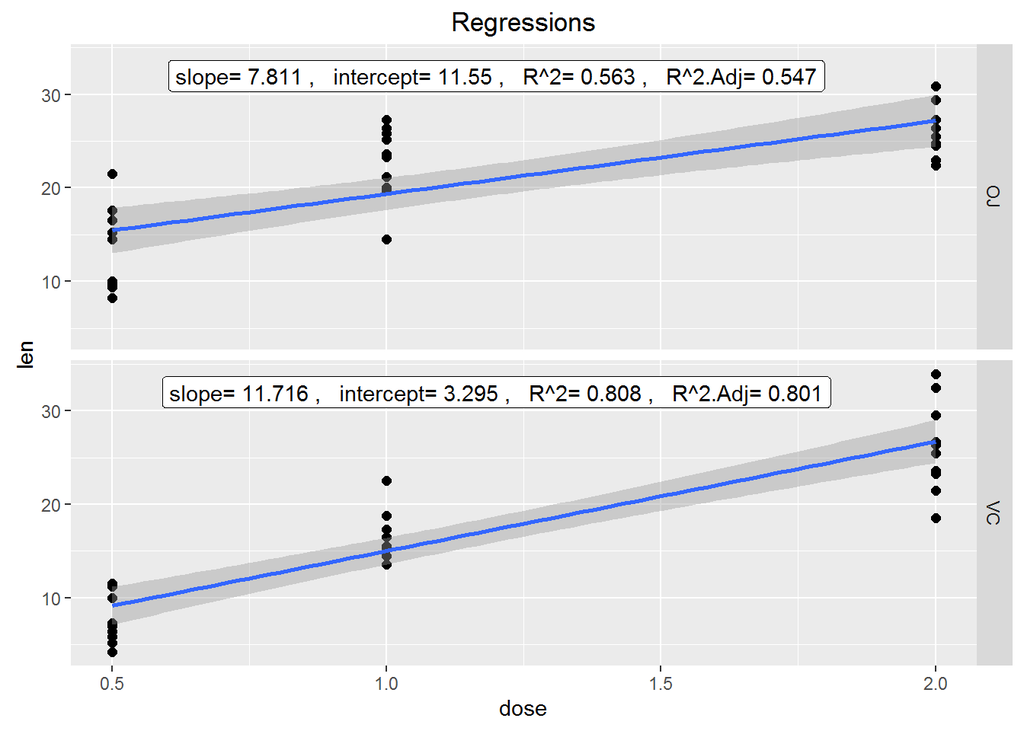

```r
#4. Let's plot all the plots and the values of the regression models.
qplot(dose, len, data = ToothGrowth, size=I(2))+geom_smooth(method="lm")+
        facet_grid(supp ~ .)+ggtitle("Regressions")+
        geom_label(data=regressions_data, inherit.aes=FALSE, aes(x = 1.2, y = 32,
label=paste("slope=",slope,","," ","intercept=",intercept,","," ","R^2=",R2,","," ","R^2.Adj=",R2.Adj)))
```

[^1]: 1. If you don’t want a rectangle underneath the text use “geom_text” insted of “geom_label”.
[^2]: 2. is possible much more customization. Check out the help file of facets_grid, geom_label, etc.